# Week1_quiz1

Q1. How many individuals in the Melanoma dataset from the MASS package died from a melanoma?

```r
library(MASS)
# status 1 means died from Melanoma
diedMelanoma <- Melanoma[Melanoma$status==1,]
nrow(diedMelanoma)
```

```
## [1] 57
```

Q2. What is the average age of individuals in the Melanoma dataset from the MASS package who are alive?

```r
library(MASS)
AliveMelanoma <- Melanoma[Melanoma$status==2,]
mean(AliveMelanoma$age)
```

```
## [1] 50.00746
```

Q3. Which animal in the mammals dataset from the MASS package has the largest brain weight relative to its body weight (that is, the largest brain weight to body weight ratio)?

```r
library(MASS)
m <- data.frame((cbind(name=rownames(mammals), BrainVsBody = (mammals$brain/1000)/mammals$body)), stringsAsFactors = FALSE)
is.data.frame(m)
```

```
## [1] TRUE
```

```r
m[m$BrainVsBody == max(m$BrainVsBody),]
```

```
##               name        BrainVsBody
## 11 Ground squirrel 0.0396039603960396
```

Q4. Create side-by-side boxplots for each of the numeric variables in the iris dataset. To do so, simply supply the usual function with a dataframe of only the numeric variables of the dataset. (Use the code block above.)

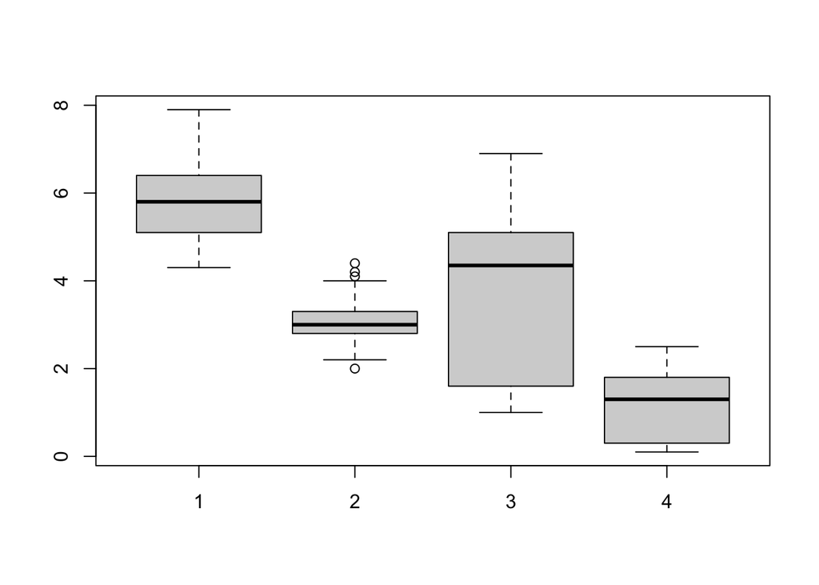

```r
boxplot(iris$Sepal.Length,iris$Sepal.Width,iris$Petal.Length, iris$Petal.Width)
```

Q5. Based on this plot, which variable is the most variable? Calculate the standard deviation of this variable. (Use the code block above.

```r
sd(iris$Petal.Length)
```

```
## [1] 1.765298
```

```r
z <-  list(c(6.85,-2.82,1.82,3.16,2.02,-0.53,7.56,-0.47,10.09,-0.31,6.52,11.43,-6.94,-1.39,-0.67,3.18,-1.42,-13.28,-12.20,6.60,-1.53,-8.91,-0.86,6.07,9.48),
c(1, 1, 2, 3, 5, 8),
c(11, 30, 12, 22,  2, 19, 17,  4,  6, 29, 14, 25, 20, 10, 18,  3, 23, 21,  9, 15,  1, 26, 28, 16,  8, 7, 24, 27, 13,  5))

min(z[[1]]) +
max(z[[2]]) +
mean(z[[3]])
```

```
## [1] 10.22
```

Q6. Where were the measurements taken in the airquality dataset?

```r
?airquality
```

New York

Q7. Using the airquality dataset, what is the average wind speed in May ?

```r
mean(airquality[airquality$Month==5,]$Wind)
```

```
## [1] 11.62258
```

Q8. Using the airquality dataset, what is the average ozone measurement? Hint: read the documentation of any function that returns an unexpected result. You will likely find a solution to the issue.

```r
mean(airquality$Ozone,na.rm = TRUE)
```

```
## [1] 42.12931
```

Q9. Using the airquality dataset, create a scatter plot to compare windspeed and temperature. Based on this plot, you believe that:

- Wind speed and temperature have no relationship.
- As temperature increases, wind speed increases.
- As temprature increases, wind speed decreases

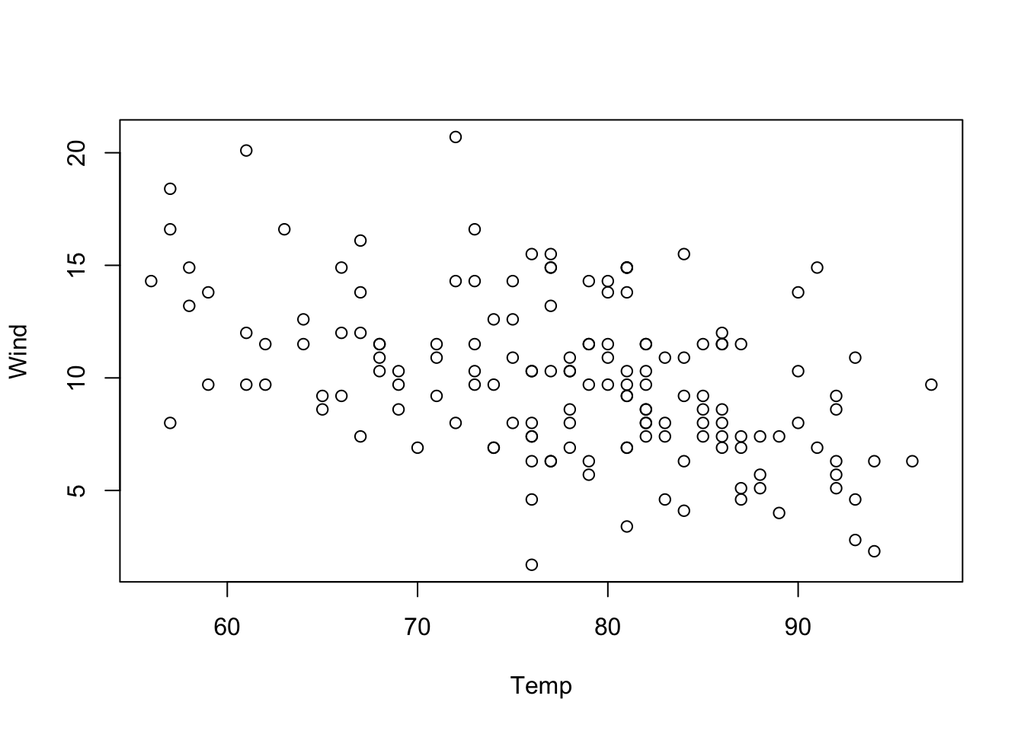

```r
library(ggplot2)
plot(Wind~Temp, data=airquality )
```

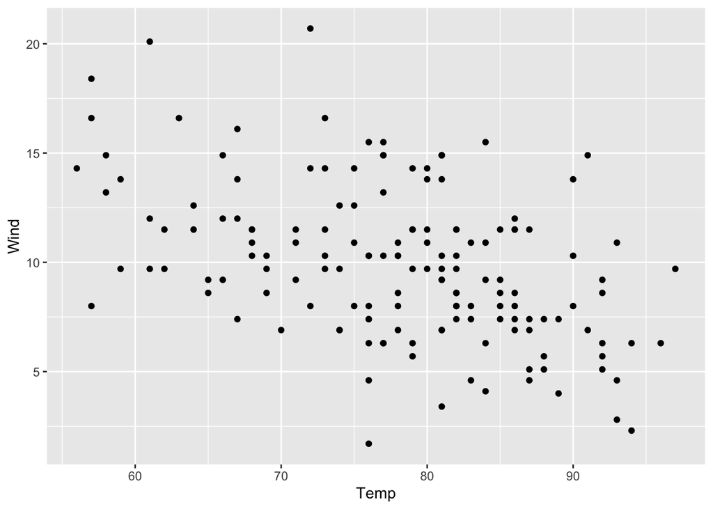

```r
ggplot(airquality, aes(x=Temp, y=Wind))+geom_point()
```

Q10. What proportion of the elements of x are larger than 2 in magnitude? Be sure to run the two lines in order, otherwise your vector will not contain the expected elements. #WRONG

```r
set.seed(1337)
x = rnorm(10000)
length(x[(x>2) | (x< -2)])/length(x)
```

```
## [1] 0.0444
```

Q11. Write a function called f that has a single argument input with a default value of 42 which is assumed to be a vector of numeric values. The function should output a vector that is input but with any negative values replaced with 0.

Hint: The ifelse() function could be useful here. Note that all three arguments to ifelse() are vectors.

Run your function followed by the three lines given. Submit the output as your answer.

```r
f <- function(input=42){
  input[input<0]=0
  return(input)
}


set.seed(42)
x = rnorm(100, mean = 0, sd = 10)
mean(f(input = x)) - f()
```

```
## [1] -37.70725
```

Q12. Create three vectors x0, x1, and y. Each should have a length of 30 and store the following:

x0: Each element should be the value 1 x1: The first 30 square numbers, starting from 1 (so 1, 4, 9, etc.) y: The result of running the given code, after creating the other two vectors Report the mean of the values stored in y.

```r
# create vectors x0 and x1
x0 <- rep(1,30)
x1 <- c(1:30)^2
set.seed(42)
y  = 5 * x0 + x1 + rnorm(n = 30, mean = 0 , sd = 1)
mean(y)
```

```
## [1] 320.2353
```

Q13. Continued from Question 12. You will need to copy and paste your code from Question 12 into the code block first before completing this question.Create a matrix X with columns x0 and x1. Report the sum of the elements in rows 17 and 19.

```r
m1 <- cbind("x0"=x0, "x1"=x1)
sum(m1[17,])+sum(m1[19,])
```

```
## [1] 652
```

```r
m1 <- cbind("x0"=x0, "x1"=x1)
beta_hat <- solve(t(m1)%*%m1)%*%t(m1)%*%y
sum(beta_hat)
```

```
## [1] 6.427899
```

Q15. Continued from Questions 12-14. You will need to copy and paste your code from Questions 12-14 into the code block first before completing this question. Create a new variable y_hat which stores the result of the matrix operation,

$\hat{y} = X \hat{\beta}$

The result will be a 30×1 matrix. Perform and report the result of the following operation,

$\sum_{i = 1}^{30} (y_i - \hat{y}_i)^ 2$

```r
x0 <- rep(1,30)
x1 <- c(1:30)^2
set.seed(42)
y  = 5 * x0 + x1 + rnorm(n = 30, mean = 0 , sd = 1)
X <- cbind("x0"=x0, "x1"=x1)

beta_hat <- solve(t(X)%*%X)%*%t(X)%*%y

y_hat <- X %*% beta_hat
# here is what y_hat looks like as a vector
y_hat[,1]
```

```
##  [1]   6.427899   9.424468  14.418749  21.410743  30.400450  41.387869
##  [7]  54.373001  69.355846  86.336403 105.314673 126.290655 149.264350
## [13] 174.235757 201.204878 230.171710 261.136256 294.098514 329.058484
## [19] 366.016167 404.971563 445.924671 488.875492 533.824026 580.770272
## [25] 629.714231 680.655902 733.595286 788.532383 845.467192 904.399714
```

```r
#now to substract each element of 2 vectors and square them
sum((y-y_hat[,1])^2)
```

```
## [1] 42.67698
```